# Model Selection and Variance Components

```r
# rmdhelp::show_knit_hook_call()
knitr::knit_hooks$set(hook_convert_odg = rmdhelp::hook_convert_odg)
```

# Disclaimer

Data and code for the demo on model selection and variance components are shown in this notebook.

# Data

The data is available from the following path

```
## /Users/pvr/Data/Projects/Github/charlotte-ngs/pigsciencess2022_gh-root/main/pigsciencess2022/docs/data/bw_bc_rand_pred.csv
```

Data is read from file by

```r
tbl_ms_vc <- readr::read_csv(file = s_ms_vc_path)
tbl_ms_vc
```

```
## # A tibble: 10 × 4
##    Animal `Breast Circumference` `Body Weight` RandPred
##     <dbl>                  <dbl>         <dbl>    <dbl>
##  1      1                    176           471      180
##  2      2                    177           463      178
##  3      3                    178           481      179
##  4      4                    179           470      182
##  5      5                    179           496      183
##  6      6                    180           491      179
##  7      7                    181           518      183
##  8      8                    182           511      181
##  9      9                    183           510      179
## 10     10                    184           541      182
```

# Descriptive Statistics

Pairs plot gives an overview

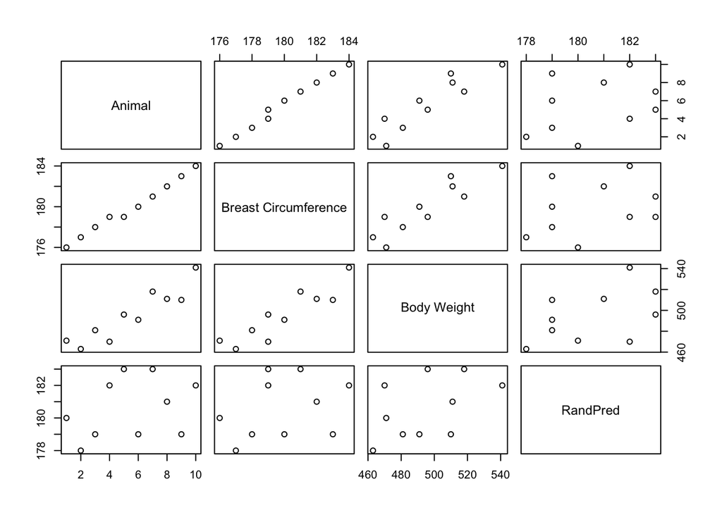

```r
pairs(tbl_ms_vc)
```

Ignore first column with animal IDs

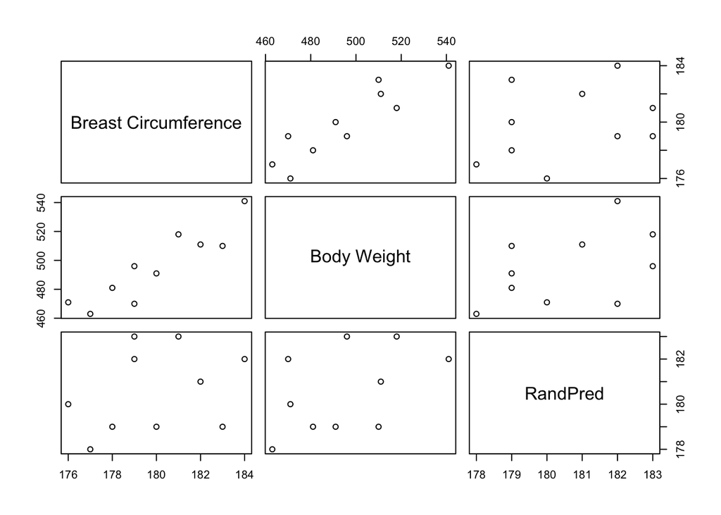

```r
pairs(tbl_ms_vc[,c("Breast Circumference", "Body Weight", "RandPred")])
```

Alternative selection with `dplyr::select()`

```r
library(dplyr)
```

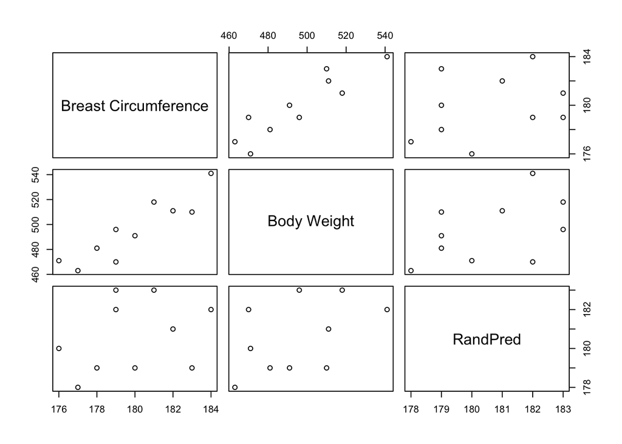

```r
pairs(tbl_ms_vc %>% select(-Animal))
```

# Model Selection

Do predictors in the model explain any variability of response at all is answered by the following analysis of variance (ANOVA)

## ANOVA

```r
aov_bw_bc_rp <- aov(formula = `Body Weight` ~ `Breast Circumference` + RandPred,
                    data = tbl_ms_vc)
(smry_aov_bw_bc_rp <- summary(aov_bw_bc_rp))
```

```
##                        Df Sum Sq Mean Sq F value   Pr(>F)
## `Breast Circumference`  1   4581    4581  42.143 0.000337 ***
## RandPred                1    221     221   2.037 0.196541
## Residuals               7    761     109
## ---
## Signif. codes:  0 '***' 0.001 '**' 0.01 '*' 0.05 '.' 0.1 ' ' 1
```

Most of the variability of the response is explained by `Breast Circumference`. `RandPred` does not explain a lot.

## Reproduction of ANOVA Results

The computations of the different sum of squares (SSQ) values are reproduced. We start with the total sum of squares ($SSQ_T$) which corresponds to the sum of the squared deviations of the observed values for the response from the overall mean of all observations.

```r
n_mean_bw <- mean(tbl_ms_vc$`Body Weight`)
n_ssq_total <- sum((tbl_ms_vc$`Body Weight` - n_mean_bw)^2)
n_ssq_total
```

```
## [1] 5563.6
```

This corresponds to the sum of all entries in column `Sum Sq` in the above ANOVA table.

```r
sum(smry_aov_bw_bc_rp[[1]][,"Sum Sq"])
```

```
## [1] 5563.6
```

The decomposition of $SSQ_T$ can be shown with a scatterplot

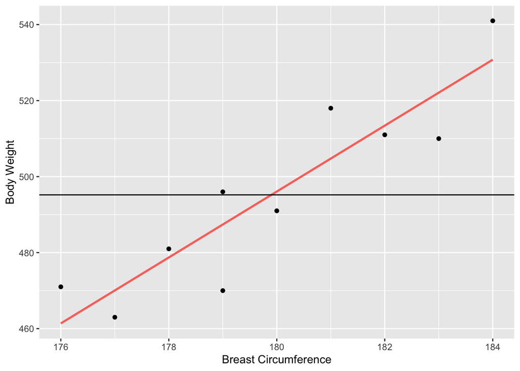

```r
p <- ggplot2::ggplot(data = tbl_ms_vc, ggplot2::aes(x = `Breast Circumference`, y = `Body Weight`)) +
  ggplot2::geom_point() +
  ggplot2::geom_smooth(method = "lm", se = FALSE, ggplot2::aes(color = "red")) +
  ggplot2::geom_hline(yintercept = n_mean_bw, ggplot2::aes(color = "greed")) +
  ggplot2::theme(legend.position = "none")
p
```

Save the plot to add more details

```r
s_plot_dir <- "pdf"
if (!dir.exists(s_plot_dir)) dir.create(path = s_plot_dir)
s_plot_file <- file.path(s_plot_dir, "ssq_reg_plot.pdf")
if (!file.exists(s_plot_file))
  ggplot2::ggsave(filename = s_plot_file, p)
```

Adding more details to the plot

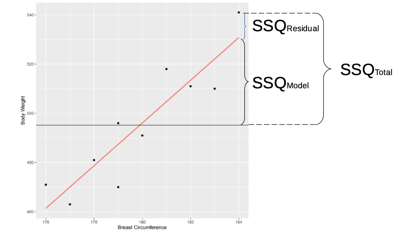

## Regression

The regression tell something about how much the response changes when the predictor changes one unit

```r
lm_bw_bc_rp <- lm(formula = `Body Weight` ~ `Breast Circumference` + RandPred,
                    data = tbl_ms_vc)
summary(lm_bw_bc_rp)
```

```
##
## Call:
## lm(formula = `Body Weight` ~ `Breast Circumference` + RandPred,
##     data = tbl_ms_vc)
##
## Residuals:
##      Min       1Q   Median       3Q      Max
## -21.9487  -2.0365   0.3772   6.7539   8.8617
##
## Coefficients:
##                         Estimate Std. Error t value Pr(>|t|)
## (Intercept)            -1464.607    368.944  -3.970 0.005394 **
## `Breast Circumference`     8.038      1.408   5.708 0.000729 ***
## RandPred                   2.845      1.993   1.427 0.196541
## ---
## Signif. codes:  0 '***' 0.001 '**' 0.01 '*' 0.05 '.' 0.1 ' ' 1
##
## Residual standard error: 10.43 on 7 degrees of freedom
## Multiple R-squared:  0.8632, Adjusted R-squared:  0.8242
## F-statistic: 22.09 on 2 and 7 DF,  p-value: 0.0009462
```

Select the best model

```r
tbl_ms_vc_olsrr <- tbl_ms_vc %>% rename(BW = `Body Weight`, BC = `Breast Circumference`)
lm_ms_vc_olsrr <- lm(BW ~ BC + RandPred, data = tbl_ms_vc_olsrr)
olsrr::ols_step_best_subset(lm_ms_vc_olsrr)
```

```
##  Best Subsets Regression
## --------------------------
## Model Index    Predictors
## --------------------------
##      1         BC
##      2         BC RandPred
## --------------------------
##
##                                                     Subsets Regression Summary
## ----------------------------------------------------------------------------------------------------------------------------------
##                        Adj.        Pred
## Model    R-Square    R-Square    R-Square     C(p)       AIC       SBIC        SBC        MSEP         FPE         HSP       APC
## ----------------------------------------------------------------------------------------------------------------------------------
##   1        0.8234      0.8014      0.7137    3.0372    80.2529    52.2776    81.1606    1235.0138    147.3596    17.5428    0.2649
##   2        0.8632      0.8242      0.7428    3.0000    79.6985    53.5238    80.9088    1116.0466    141.3176    18.1176    0.2540
## ----------------------------------------------------------------------------------------------------------------------------------
## AIC: Akaike Information Criteria
##  SBIC: Sawa's Bayesian Information Criteria
##  SBC: Schwarz Bayesian Criteria
##  MSEP: Estimated error of prediction, assuming multivariate normality
##  FPE: Final Prediction Error
##  HSP: Hocking's Sp
##  APC: Amemiya Prediction Criteria
```

```r
MASS::stepAIC(lm_ms_vc_olsrr)
```

```
## Start:  AIC=49.32
## BW ~ BC + RandPred
##
##            Df Sum of Sq    RSS    AIC
## <none>                   760.9 49.320
## - RandPred  1     221.5  982.4 49.874
## - BC        1    3541.6 4302.5 64.644
```

```
##
## Call:
## lm(formula = BW ~ BC + RandPred, data = tbl_ms_vc_olsrr)
##
## Coefficients:
## (Intercept)           BC     RandPred
##   -1464.607        8.038        2.845
```

# Variance Components

Adding sires to the data

```r
tbl_ms_vc_sire <- tbl_ms_vc
tbl_ms_vc_sire$Sire <- c(rep(1,3), rep(2,3), rep(3,4))
tbl_ms_vc_sire
```

```
## # A tibble: 10 × 5
##    Animal `Breast Circumference` `Body Weight` RandPred  Sire
##     <dbl>                  <dbl>         <dbl>    <dbl> <dbl>
##  1      1                    176           471      180     1
##  2      2                    177           463      178     1
##  3      3                    178           481      179     1
##  4      4                    179           470      182     2
##  5      5                    179           496      183     2
##  6      6                    180           491      179     2
##  7      7                    181           518      183     3
##  8      8                    182           511      181     3
##  9      9                    183           510      179     3
## 10     10                    184           541      182     3
```

Convert sire column to factor

```r
tbl_ms_vc_sire$Sire <- as.factor(tbl_ms_vc_sire$Sire)
tbl_ms_vc_sire
```

```
## # A tibble: 10 × 5
##    Animal `Breast Circumference` `Body Weight` RandPred Sire
##     <dbl>                  <dbl>         <dbl>    <dbl> <fct>
##  1      1                    176           471      180 1
##  2      2                    177           463      178 1
##  3      3                    178           481      179 1
##  4      4                    179           470      182 2
##  5      5                    179           496      183 2
##  6      6                    180           491      179 2
##  7      7                    181           518      183 3
##  8      8                    182           511      181 3
##  9      9                    183           510      179 3
## 10     10                    184           541      182 3
```

Simplify computations with a balanced dataset

```r
tbl_ms_vc_sire <- tbl_ms_vc_sire[1:9,]
```

ANOVA

```r
aov_ms_vc_sire <- aov(`Body Weight` ~ Sire, data = tbl_ms_vc_sire)
smry_aov_ms_vc_sire <- summary(aov_ms_vc_sire)
smry_aov_ms_vc_sire
```

```
##             Df Sum Sq Mean Sq F value  Pr(>F)
## Sire         2 2651.6  1325.8   13.68 0.00581 **
## Residuals    6  581.3    96.9
## ---
## Signif. codes:  0 '***' 0.001 '**' 0.01 '*' 0.05 '.' 0.1 ' ' 1
```

What is the variance of the sire effect? Use the fact that

$$E(MSQ_R) = \sigma_e^2$$
Hence $\widehat{\sigma_e^2} = MSQ_R = 96.8888889$.

Furthermore

$$E(MSQ_S) = n_S * \sigma_S^2 + \sigma_e^2$$

Hence

$$\widehat{\sigma_S^2} = \frac{MSQ_S - MSQ_R}{n_S} =
\frac{1325.7777778 - 96.8888889}{3}$$

```r
n_sigma_s2 <- (smry_aov_ms_vc_sire[[1]]["Sire", "Mean Sq"] - smry_aov_ms_vc_sire[[1]]["Residuals", "Mean Sq"]) / 3
n_sigma_s2
```

```
## [1] 409.6296
```

lme4

```r
lmer_ms_vc_sire <- lme4::lmer(`Body Weight` ~ (1|Sire), data = tbl_ms_vc_sire)
summary(lmer_ms_vc_sire)
```

```
## Linear mixed model fit by REML ['lmerMod']
## Formula: `Body Weight` ~ (1 | Sire)
##    Data: tbl_ms_vc_sire
##
## REML criterion at convergence: 66.7
##
## Scaled residuals:
##      Min       1Q   Median       3Q      Max
## -1.62462 -0.20467 -0.03325  0.67790  1.01679
##
## Random effects:
##  Groups   Name        Variance Std.Dev.
##  Sire     (Intercept) 409.63   20.239
##  Residual              96.89    9.843
## Number of obs: 9, groups:  Sire, 3
##
## Fixed effects:
##             Estimate Std. Error t value
## (Intercept)   490.11      12.14   40.38
```